# PICO analysis

Kim Dill-McFarland

version August 14, 2018

# Setup

Set seed for reproducibility

```r
set.seed(2486)
```

## Packages

```r
#Community Ecology Package: Ordination, Diversity and Dissimilarities
library(vegan)
```

```r
#Handling and analysis of high-throughput phylogenetic sequence data.
library(phyloseq)
#Data manipulation and plotting
library(tidyverse)
#Nonparametric Tests for Repeated Measures Data in Factorial Designs
library(nparLD)
#Fisheries stock assessment methods and data
#Dunn's Kruskal-Wallis Multiple Comparisons
library(FSA)
```

## Data

### Import data

Import microbiome data at OTU, genus, and family levels

```r
OTU = read.table("data/PICO.OTU.txt", header=TRUE, row.names=1, sep="\t")
genus = read.table("data/Genus.txt", header=TRUE, row.names=1, sep="\t")
family = read.table("data/Family.txt", header=TRUE, row.names=1, sep="\t")
```

Import full taxonomies of OTUs

```r
tax = read.table("data/PICO.tax.taxonomy", header=TRUE, sep="\t", row.names=1)
```

Import metadata of samples including alpha-diversity measures

```r
meta = read.table("data/PICO.meta.txt", header=TRUE, row.names=1, sep="\t")
```

### Sort data

Sort data by sample names.

```r
OTU = OTU[order(row.names(OTU)),]
genus = genus[(row.names(genus)),]
family = family[(row.names(family)),]
meta = meta[order(row.names(meta)),]
```

### Create variables

Create a pairwise variable for Treatment:Time_point

```r
meta$treat_time = paste(meta$Treatment, meta$Time_Point, sep="_")
```

## Functions

Load necessary custom functions

```r
#Function to run pairwise PERMANOVAs of all levels of a variable of interest across beta-diversity measures
source("scripts/pairwise_adonis_all.R")

#Similarity percentages (SIMPER) analysis of multiple variables
source("scripts/simper.R")

#Nonparametric Tests for Repeated Measures Data in Factorial Designs across multiple taxa
source("scripts/nparLD.R")

#Dunn's Kruskal-Wallis Multiple Comparisons across multiple taxa
source("scripts/dunn.R")
```

# Beta-diversity

## Calculate

```r
BC.dist=as.matrix(vegdist(OTU, distance="bray"))
J.dist=as.matrix(vegdist(OTU, distance="jaccard"))
```

## PERMANOVA

Model: Treatment*Time_Point with Treatment:Time_Point removed if not significant

```r
adonis(BC.dist ~ Treatment+as.factor(Time_Point), strata=as.factor(meta$Subject_ID), data = meta, permutations = 1000)
```

```
##
## Call:
## adonis(formula = BC.dist ~ Treatment + as.factor(Time_Point),      data = meta, permutations = 1000, strata = as.factor(meta$Subject_ID))
##
## Blocks:  strata
## Permutation: free
## Number of permutations: 1000
##
## Terms added sequentially (first to last)
##
##                       Df SumsOfSqs MeanSqs F.Model      R2   Pr(>F)
## Treatment              1    0.6961 0.69611  1.8343 0.02218 0.000999 ***
## as.factor(Time_Point)  2    1.0819 0.54093  1.4254 0.03448 0.000999 ***
## Residuals             78   29.6006 0.37949         0.94334
## Total                 81   31.3785                 1.00000
## ---
## Signif. codes:  0 '***' 0.001 '**' 0.01 '*' 0.05 '.' 0.1 ' ' 1
```

```r
adonis(J.dist ~ Treatment+as.factor(Time_Point), strata=as.factor(meta$Subject_ID), data = meta, permutations = 1000)
```

```
##
## Call:
## adonis(formula = J.dist ~ Treatment + as.factor(Time_Point),      data = meta, permutations = 1000, strata = as.factor(meta$Subject_ID))
##
## Blocks:  strata
## Permutation: free
## Number of permutations: 1000
##
## Terms added sequentially (first to last)
##
##                       Df SumsOfSqs MeanSqs F.Model      R2   Pr(>F)
## Treatment              1    0.6961 0.69611  1.8343 0.02218 0.000999 ***
## as.factor(Time_Point)  2    1.0819 0.54093  1.4254 0.03448 0.000999 ***
## Residuals             78   29.6006 0.37949         0.94334
## Total                 81   31.3785                 1.00000
## ---
## Signif. codes:  0 '***' 0.001 '**' 0.01 '*' 0.05 '.' 0.1 ' ' 1
```

## Pairwise PERMANOVA

Model: Pairwise within Treatment:Time_Point groups

Within treatment, across time, strata by subject

```r
pairwise.adonis.all(OTU, meta, factors=meta$treat_time, sim.method="bray", stratify=TRUE, strata.factor=meta$Subject_ID, p.adjust.m="fdr")
```

[output not shown]

[output not shown]

[output not shown]

[output not shown]

[output not shown]

[output not shown]

[output not shown]

[output not shown]

[output not shown]

[output not shown]

[output not shown]

[output not shown]

[output not shown]

[output not shown]

[output not shown]

[output not shown]

[output not shown]

[output not shown]

[output not shown]

```
##                     pairs   F.Model         R2 p.value p.adjusted
## 1  Placebo_0 vs Placebo_4 0.8960113 0.03599015   0.255     0.3060
## 2  Placebo_0 vs Placebo_8 1.1009292 0.04567995   0.028     0.0840
## 3     Placebo_0 vs Drug_0 0.9849814 0.03790580      NA         NA
## 4     Placebo_0 vs Drug_4 1.1548310 0.04415364      NA         NA
## 5     Placebo_0 vs Drug_8 1.9307970 0.07744626      NA         NA
## 6  Placebo_4 vs Placebo_8 0.7266190 0.02824386   0.077     0.1365
## 7     Placebo_4 vs Drug_0 1.5851333 0.05545307      NA         NA
## 8     Placebo_4 vs Drug_4 1.0585043 0.03772490      NA         NA
## 9     Placebo_4 vs Drug_8 1.8686655 0.06954813      NA         NA
## 10    Placebo_8 vs Drug_0 1.2400912 0.04552449      NA         NA
## 11    Placebo_8 vs Drug_4 0.6025125 0.02264871      NA         NA
## 12    Placebo_8 vs Drug_8 0.7658045 0.03092185      NA         NA
## 13       Drug_0 vs Drug_4 1.1429399 0.03921841   0.091     0.1365
## 14       Drug_0 vs Drug_8 1.2684822 0.04651826   0.027     0.0840
## 15       Drug_4 vs Drug_8 0.5401157 0.02035092   0.583     0.5830
```

```r
pairwise.adonis.all(OTU, meta, factors=meta$treat_time, sim.method="jaccard", stratify=TRUE, strata.factor=meta$Subject_ID, p.adjust.m="fdr")
```

[output not shown]

[output not shown]

[output not shown]

[output not shown]

[output not shown]

[output not shown]

[output not shown]

[output not shown]

[output not shown]

[output not shown]

[output not shown]

[output not shown]

[output not shown]

[output not shown]

[output not shown]

[output not shown]

[output not shown]

[output not shown]

[output not shown]

```
##                     pairs   F.Model         R2 p.value p.adjusted
## 1  Placebo_0 vs Placebo_4 0.8960113 0.03599015   0.278     0.3336
## 2  Placebo_0 vs Placebo_8 1.1009292 0.04567995   0.025     0.1050
## 3     Placebo_0 vs Drug_0 0.9849814 0.03790580      NA         NA
## 4     Placebo_0 vs Drug_4 1.1548310 0.04415364      NA         NA
## 5     Placebo_0 vs Drug_8 1.9307970 0.07744626      NA         NA
## 6  Placebo_4 vs Placebo_8 0.7266190 0.02824386   0.071     0.1420
## 7     Placebo_4 vs Drug_0 1.5851333 0.05545307      NA         NA
## 8     Placebo_4 vs Drug_4 1.0585043 0.03772490      NA         NA
## 9     Placebo_4 vs Drug_8 1.8686655 0.06954813      NA         NA
## 10    Placebo_8 vs Drug_0 1.2400912 0.04552449      NA         NA
## 11    Placebo_8 vs Drug_4 0.6025125 0.02264871      NA         NA
## 12    Placebo_8 vs Drug_8 0.7658045 0.03092185      NA         NA
## 13       Drug_0 vs Drug_4 1.1429399 0.03921841   0.116     0.1740
## 14       Drug_0 vs Drug_8 1.2684822 0.04651826   0.035     0.1050
## 15       Drug_4 vs Drug_8 0.5401157 0.02035092   0.549     0.5490
```

Within time, between treatments

```r
pairwise.adonis.all(OTU, meta, factors=meta$treat_time, sim.method="bray", stratify=FALSE, p.adjust.m="fdr")
```

```
##                     pairs   F.Model         R2 p.value p.adjusted
## 1  Placebo_0 vs Placebo_4 0.8960113 0.03599015   0.583  0.7950000
## 2  Placebo_0 vs Placebo_8 1.1009292 0.04567995   0.320  0.6000000
## 3     Placebo_0 vs Drug_0 0.9849814 0.03790580   0.471  0.7065000
## 4     Placebo_0 vs Drug_4 1.1548310 0.04415364   0.224  0.5442857
## 5     Placebo_0 vs Drug_8 1.9307970 0.07744626   0.009  0.1350000
## 6  Placebo_4 vs Placebo_8 0.7266190 0.02824386   0.770  0.9426923
## 7     Placebo_4 vs Drug_0 1.5851333 0.05545307   0.044  0.2200000
## 8     Placebo_4 vs Drug_4 1.0585043 0.03772490   0.383  0.6383333
## 9     Placebo_4 vs Drug_8 1.8686655 0.06954813   0.022  0.1650000
## 10    Placebo_8 vs Drug_0 1.2400912 0.04552449   0.125  0.4687500
## 11    Placebo_8 vs Drug_4 0.6025125 0.02264871   0.981  0.9810000
## 12    Placebo_8 vs Drug_8 0.7658045 0.03092185   0.817  0.9426923
## 13       Drug_0 vs Drug_4 1.1429399 0.03921841   0.254  0.5442857
## 14       Drug_0 vs Drug_8 1.2684822 0.04651826   0.160  0.4800000
## 15       Drug_4 vs Drug_8 0.5401157 0.02035092   0.969  0.9810000
```

```r
pairwise.adonis.all(OTU, meta, factors=meta$treat_time, sim.method="jaccard", stratify=FALSE, p.adjust.m="fdr")
```

```
##                     pairs   F.Model         R2 p.value p.adjusted
## 1  Placebo_0 vs Placebo_4 0.8960113 0.03599015   0.563  0.7677273
## 2  Placebo_0 vs Placebo_8 1.1009292 0.04567995   0.300  0.5625000
## 3     Placebo_0 vs Drug_0 0.9849814 0.03790580   0.478  0.7170000
## 4     Placebo_0 vs Drug_4 1.1548310 0.04415364   0.207  0.5175000
## 5     Placebo_0 vs Drug_8 1.9307970 0.07744626   0.007  0.1050000
## 6  Placebo_4 vs Placebo_8 0.7266190 0.02824386   0.785  0.9461538
## 7     Placebo_4 vs Drug_0 1.5851333 0.05545307   0.024  0.1700000
## 8     Placebo_4 vs Drug_4 1.0585043 0.03772490   0.373  0.6216667
## 9     Placebo_4 vs Drug_8 1.8686655 0.06954813   0.034  0.1700000
## 10    Placebo_8 vs Drug_0 1.2400912 0.04552449   0.134  0.4500000
## 11    Placebo_8 vs Drug_4 0.6025125 0.02264871   0.979  0.9790000
## 12    Placebo_8 vs Drug_8 0.7658045 0.03092185   0.820  0.9461538
## 13       Drug_0 vs Drug_4 1.1429399 0.03921841   0.258  0.5528571
## 14       Drug_0 vs Drug_8 1.2684822 0.04651826   0.150  0.4500000
## 15       Drug_4 vs Drug_8 0.5401157 0.02035092   0.960  0.9790000
```

## SIMPER

Similarity percentages of Treatment:Time_Point at OTU, genus, and family levels

```r
simper.pretty(x=OTU, metrics=meta, interesting="treat_time", perc_cutoff=1, low_cutoff='n', output_name="results/simper/OTU")

simper.pretty(x=genus, metrics=meta, interesting="treat_time", perc_cutoff=1, low_cutoff='n', low_val=0.001, output_name="results/simper/Genus")

simper.pretty(x=family, metrics=meta, interesting="treat_time", perc_cutoff=1, low_cutoff='n', output_name="results/simper/Family")
```

### Merge results

Read in SIMPER results and select at cutoffs

- OTUs and genera: minimum 2%
- families: minimum 5%

```r
OTU.simper = read.csv("results/simper/OTU_clean_simper.csv") %>%
  mutate(level="OTU") %>%
  filter(SIMPER>=0.02)

gen.simper = read.csv("results/simper/Genus_clean_simper.csv") %>%
  mutate(level="genus") %>%
  filter(SIMPER>=0.02)

fam.simper = read.csv("results/simper/Family_clean_simper.csv") %>%
  mutate(level="family") %>%
  filter(SIMPER>=0.05)
```

Merge and select comparisons of interest

```r
all.simper = OTU.simper %>%
  rbind(gen.simper) %>%
  rbind(fam.simper) %>%
  dplyr::select(-X) %>%
  rename(taxon=OTU) %>%
  filter(Comparison %in% c("Placebo_0_Placebo_4",
                           "Placebo_4_Placebo_8",
                           "Placebo_0_Placebo_8",
                           "Drug_0_Drug_4",
                           "Drug_4_Drug_8",
                           "Drug_0_Drug_8",
                           "Placebo_0_Drug_0",
                           "Placebo_4_Drug_4",
                           "Placebo_8_Drug_8"))

write.csv(all.simper, "results/simper/all.simper.csv", row.names=FALSE)
```

Determine unique taxa lists of interest

```r
unique(all.simper$taxon)
```

```
##  [1] Otu00001               Otu00006               Otu00005
##  [4] Otu00002               Otu00032               Otu00007
##  [7] Otu00019               Otu00024               Otu00010
## [10] Otu00008               Otu00027               Otu00004
## [13] Otu00003               Otu00016               Otu00009
## [16] Otu00015               Otu00017               Otu00011
## [19] Otu00025               Otu00013               Otu00012
## [22] Otu00014               Otu00018               Otu00023
## [25] unclassified           g__Streptococcus       g__Enterococcus
## [28] g__Blautia             g__Lactobacillus       g__Akkermansia
## [31] g__Bifidobacterium     g__Clostridium         g__Dorea
## [34] g__Ruminococcus_L      g__Bacteroides         g__Escherichia
## [37] g__Prevotella          g__Ruminococcus_R      g__Coprococcus
## [40] g__Collinsella         g__Veillonella         g__Roseburia
## [43] g__Faecalibacterium    f__Lachnospiraceae     f__Streptococcaceae
## [46] f__Enterococcaceae     f__Ruminococcaceae     f__Lactobacillaceae
## [49] f__Enterobacteriaceae  f__Verrucomicrobiaceae f__Bifidobacteriaceae
## [52] f__Clostridiaceae      f__Veillonellaceae
## 2392 Levels: Otu00001 Otu00002 Otu00003 Otu00004 Otu00005 ... f__Xanthomonadaceae
```

# Taxa of interest

## ANOVA-like nparLD

Nonparametric Tests for the F1-LD-F1 Design for taxa selected in SIMPER

For OTUs

```r
OTU.list = c("Otu00001","Otu00002","Otu00003","Otu00004","Otu00005","Otu00006","Otu00007","Otu00008","Otu00009","Otu00010","Otu00011","Otu00012","Otu00013","Otu00014","Otu00015","Otu00016","Otu00017","Otu00019","Otu00023","Otu00024","Otu00025","Otu00027","Otu00032")

nparLD.pval.fxn(OTU, OTU.list, "results/nparLD/OTU")
```

For genera

```r
genus.list = c("g__Akkermansia","g__Bacteroides","g__Bifidobacterium","g__Blautia","g__Clostridium","g__Collinsella","g__Coprococcus","g__Dorea","g__Enterococcus","g__Escherichia","g__Faecalibacterium","g__Lactobacillus","g__Prevotella","g__Roseburia","g__Ruminococcus_L","g__Ruminococcus_R","g__Streptococcus","g__Veillonella")

nparLD.pval.fxn(genus, genus.list, "results/nparLD/genus")
```

For families

```r
fam.list = c("f__Bifidobacteriaceae","f__Clostridiaceae","f__Enterobacteriaceae","f__Enterococcaceae","f__Lachnospiraceae","f__Lactobacillaceae","f__Ruminococcaceae","f__Streptococcaceae","f__Veillonellaceae","f__Verrucomicrobiaceae")

nparLD.pval.fxn(family, fam.list, "results/nparLD/family")
```

### Merge results

Read in results

```r
OTU.nparLD.pval = read.csv("results/nparLD/OTU.nparLD.csv")
genus.nparLD.pval = read.csv("results/nparLD/genus.nparLD.csv")
fam.nparLD.pval = read.csv("results/nparLD/family.nparLD.csv")
```

Merge, reformat, and save

```r
nparLD.pval = OTU.nparLD.pval %>%
  rbind(genus.nparLD.pval) %>%
  rbind(fam.nparLD.pval) %>%
  filter(test=="aov") %>%
  dplyr::select(-test) %>%
  group_by(taxon) %>%
  spread(key=variable, value=pval)

write.csv(nparLD.pval, "results/nparLD/all.nparLD.pval.csv", row.names=FALSE)
```

## FDR correction

FDR correct nparLD p-values

For OTUs

```r
OTU.nparLD.fdr = OTU.nparLD.pval %>%
  # Combing statistical test and variable into 1 term and remove originals
  mutate(group=paste(test, variable, sep="_")) %>%
  dplyr::select(-test, -variable) %>%
  # Reformat to wide format
  spread(key=group, value=pval) %>%
  # FDR correct pvals for each test_variable
  mutate_if(is.numeric, funs(fdr = p.adjust(., method='fdr'))) %>%
  # Remove original pvals
  dplyr::select(taxon, contains("fdr"))

write.csv(OTU.nparLD.fdr, "results/nparLD/OTU.nparLD.fdr.csv", row.names=FALSE)
```

For genera

```r
genus.nparLD.fdr = genus.nparLD.pval %>%
  # Combing statistical test and variable into 1 term and remove originals
  mutate(group=paste(test, variable, sep="_")) %>%
  dplyr::select(-test, -variable) %>%
  # Reformat to wide format
  spread(key=group, value=pval) %>%
  # FDR correct pvals for each test_variable
  mutate_if(is.numeric, funs(fdr = p.adjust(., method='fdr'))) %>%
  # Remove original pvals
  dplyr::select(taxon, contains("fdr"))

write.csv(genus.nparLD.fdr, "results/nparLD/genus.nparLD.fdr.csv", row.names=FALSE)
```

For families

```r
fam.nparLD.fdr = fam.nparLD.pval %>%
  # Combing statistical test and variable into 1 term and remove originals
  mutate(group=paste(test, variable, sep="_")) %>%
  dplyr::select(-test, -variable) %>%
  # Reformat to wide format
  spread(key=group, value=pval) %>%
  # FDR correct pvals for each test_variable
  mutate_if(is.numeric, funs(fdr = p.adjust(., method='fdr'))) %>%
  # Remove original pvals
  dplyr::select(taxon, contains("fdr"))

write.csv(fam.nparLD.fdr, "results/nparLD/family.nparLD.fdr.csv", row.names=FALSE)
```

### Merge results

Read in and merge FDR corrected nparLD p-values

```r
nparLD.fdr = OTU.nparLD.fdr %>%
  rbind(genus.nparLD.fdr) %>%
  rbind(fam.nparLD.fdr) %>%
  dplyr::select(taxon, starts_with("aov_"))

write.csv(nparLD.fdr, "results/nparLD/all.nparLD.fdr.csv", row.names=FALSE)
```

## Pairwise Dunn

Dunn’s Kruskal-Wallis Multiple Comparisons for taxa selected in SIMPER

For OTUs

```r
OTU.list2=c("Otu00002", "Otu00003", "Otu00004", "Otu00005", "Otu00006", "Otu00008", "Otu00014", "Otu00015", "Otu00017", "Otu00024", "Otu00025", "Otu00027")

dunn.pval.fxn(OTU, OTU.list2, "results/dunn/OTU")
```

For genera

```r
genus.list2 = c("g__Bacteroides", "g__Collinsella", "g__Enterococcus", "g__Escherichia", "g__Roseburia", "g__Ruminococcus_L", "g__Akkermansia", "g__Clostridium", "g__Lactobacillus")

dunn.pval.fxn(genus, genus.list2, "results/dunn/genus")
```

For families

```r
family.list2=c("f__Enterobacteriaceae", "f__Enterococcaceae", "f__Lachnospiraceae", "f__Verrucomicrobiaceae")

dunn.pval.fxn(family, family.list2, "results/dunn/family")
```

### Merge results

Read in Dunn results

```r
OTU.dunn.fdr = read.csv("results/dunn/OTU.dunn.fdr.csv")
genus.dunn.fdr = read.csv("results/dunn/genus.dunn.fdr.csv")
fam.dunn.fdr = read.csv("results/dunn/family.dunn.fdr.csv")
```

Merge, select comparisons of interest, and save

```r
dunn.fdr = OTU.dunn.fdr %>%
  rbind(genus.dunn.fdr) %>%
  rbind(fam.dunn.fdr) %>%
  filter(!(label %in% c("0_Drug - 4_Placebo",
                        "0_Drug - 8_Placebo",
                        "4_Placebo - 8_Drug",
                        "0_Placebo - 4_Drug",
                        "0_Placebo - 8_Drug",
                        "4_Drug - 8_Placebo"))) %>%
  group_by(taxon) %>%
  spread(key=label, value=fdr_pval)

write.csv(dunn.fdr, "results/dunn/all.dunn.fdr.csv", row.names=FALSE)
```

## Summarise results

Merge all nparLD and Dunn p-values.

```r
tax.temp = tax %>%
  rownames_to_column() %>%
  rename(taxon=rowname) %>%
  dplyr::select(taxon, Family, Genus)

all.fdr = nparLD.fdr %>%
  right_join(dunn.fdr, by="taxon") %>%
  left_join(tax.temp, by="taxon")
write.csv(all.fdr, "results/all.npar.dunn.fdr.csv", row.names=FALSE)
```

## Mean +/- s.d.

Determine mean and standard deviation of abundances of taxa of interest within Treatment:Time_Point groups

Calculate abundances

```r
gen.abund = genus/rowSums(genus)
fam.abund = family/rowSums(family)
```

### Bacteroides

```r
mean(gen.abund[meta$Time_Point == 0 & meta$Treatment == "Placebo" ,]$g__Bacteroides*100)
```

```
## [1] 4.935748
```

```r
sd(gen.abund[meta$Time_Point == 0 & meta$Treatment == "Placebo" ,]$g__Bacteroides*100)
```

```
## [1] 7.653574
```

```r
mean(gen.abund[meta$Time_Point == 4 & meta$Treatment == "Placebo" ,]$g__Bacteroides*100)
```

```
## [1] 1.515562
```

```r
sd(gen.abund[meta$Time_Point == 4 & meta$Treatment == "Placebo" ,]$g__Bacteroides*100)
```

```
## [1] 2.900627
```

```r
mean(gen.abund[meta$Time_Point == 8 & meta$Treatment == "Placebo" ,]$g__Bacteroides*100)
```

```
## [1] 1.625566
```

```r
sd(gen.abund[meta$Time_Point == 8 & meta$Treatment == "Placebo" ,]$g__Bacteroides*100)
```

```
## [1] 3.581518
```

```r
###

mean(gen.abund[meta$Time_Point == 0 & meta$Treatment == "Drug" ,]$g__Bacteroides*100)
```

```
## [1] 2.241711
```

```r
sd(gen.abund[meta$Time_Point == 0 & meta$Treatment == "Drug" ,]$g__Bacteroides*100)
```

```
## [1] 6.891377
```

```r
mean(gen.abund[meta$Time_Point == 4 & meta$Treatment == "Drug" ,]$g__Bacteroides*100)
```

```
## [1] 0.08733937
```

```r
sd(gen.abund[meta$Time_Point == 4 & meta$Treatment == "Drug" ,]$g__Bacteroides*100)
```

```
## [1] 0.1880266
```

```r
mean(gen.abund[meta$Time_Point == 8 & meta$Treatment == "Drug" ,]$g__Bacteroides*100)
```

```
## [1] 0.995586
```

```r
sd(gen.abund[meta$Time_Point == 8 & meta$Treatment == "Drug" ,]$g__Bacteroides*100)
```

```
## [1] 2.444368
```

### Ruminococcus_L

```r
mean(gen.abund[meta$Time_Point == 0 & meta$Treatment == "Placebo" ,]$g__Ruminococcus_L*100)
```

```
## [1] 5.473395
```

```r
sd(gen.abund[meta$Time_Point == 0 & meta$Treatment == "Placebo" ,]$g__Ruminococcus_L*100)
```

```
## [1] 7.33377
```

```r
mean(gen.abund[meta$Time_Point == 4 & meta$Treatment == "Placebo" ,]$g__Ruminococcus_L*100)
```

```
## [1] 2.037039
```

```r
sd(gen.abund[meta$Time_Point == 4 & meta$Treatment == "Placebo" ,]$g__Ruminococcus_L*100)
```

```
## [1] 3.364184
```

```r
mean(gen.abund[meta$Time_Point == 8 & meta$Treatment == "Placebo" ,]$g__Ruminococcus_L*100)
```

```
## [1] 11.3261
```

```r
sd(gen.abund[meta$Time_Point == 8 & meta$Treatment == "Placebo" ,]$g__Ruminococcus_L*100)
```

```
## [1] 14.18201
```

```r
###

mean(gen.abund[meta$Time_Point == 0 & meta$Treatment == "Drug" ,]$g__Ruminococcus_L*100)
```

```
## [1] 4.472326
```

```r
sd(gen.abund[meta$Time_Point == 0 & meta$Treatment == "Drug" ,]$g__Ruminococcus_L*100)
```

```
## [1] 8.437927
```

```r
mean(gen.abund[meta$Time_Point == 4 & meta$Treatment == "Drug" ,]$g__Ruminococcus_L*100)
```

```
## [1] 7.541525
```

```r
sd(gen.abund[meta$Time_Point == 4 & meta$Treatment == "Drug" ,]$g__Ruminococcus_L*100)
```

```
## [1] 9.787987
```

```r
mean(gen.abund[meta$Time_Point == 8 & meta$Treatment == "Drug" ,]$g__Ruminococcus_L*100)
```

```
## [1] 13.78263
```

```r
sd(gen.abund[meta$Time_Point == 8 & meta$Treatment == "Drug" ,]$g__Ruminococcus_L*100)
```

```
## [1] 19.00898
```

### Verrucomicrobiaceae

```r
mean(fam.abund[meta$Time_Point == 0 & meta$Treatment == "Placebo" ,]$f__Verrucomicrobiaceae*100)
```

```
## [1] 7.532012
```

```r
sd(fam.abund[meta$Time_Point == 0 & meta$Treatment == "Placebo" ,]$f__Verrucomicrobiaceae*100)
```

```
## [1] 14.38547
```

```r
mean(fam.abund[meta$Time_Point == 4 & meta$Treatment == "Placebo" ,]$f__Verrucomicrobiaceae*100)
```

```
## [1] 4.19313
```

```r
sd(fam.abund[meta$Time_Point == 4 & meta$Treatment == "Placebo" ,]$f__Verrucomicrobiaceae*100)
```

```
## [1] 10.16118
```

```r
mean(fam.abund[meta$Time_Point == 8 & meta$Treatment == "Placebo" ,]$f__Verrucomicrobiaceae*100)
```

```
## [1] 3.75033
```

```r
sd(fam.abund[meta$Time_Point == 8 & meta$Treatment == "Placebo" ,]$f__Verrucomicrobiaceae*100)
```

```
## [1] 10.01492
```

```r
###

mean(fam.abund[meta$Time_Point == 0 & meta$Treatment == "Drug" ,]$f__Verrucomicrobiaceae*100)
```

```
## [1] 0.8472772
```

```r
sd(fam.abund[meta$Time_Point == 0 & meta$Treatment == "Drug" ,]$f__Verrucomicrobiaceae*100)
```

```
## [1] 2.636724
```

```r
mean(fam.abund[meta$Time_Point == 4 & meta$Treatment == "Drug" ,]$f__Verrucomicrobiaceae*100)
```

```
## [1] 0.1234638
```

```r
sd(fam.abund[meta$Time_Point == 4 & meta$Treatment == "Drug" ,]$f__Verrucomicrobiaceae*100)
```

```
## [1] 0.3220946
```

```r
mean(fam.abund[meta$Time_Point == 8 & meta$Treatment == "Drug" ,]$f__Verrucomicrobiaceae*100)
```

```
## [1] 1.474631
```

```r
sd(fam.abund[meta$Time_Point == 8 & meta$Treatment == "Drug" ,]$f__Verrucomicrobiaceae*100)
```

```
## [1] 4.90139
```

# Alpha-diversity

## Normality

Check normalilty of Shannon’s diveristy metric

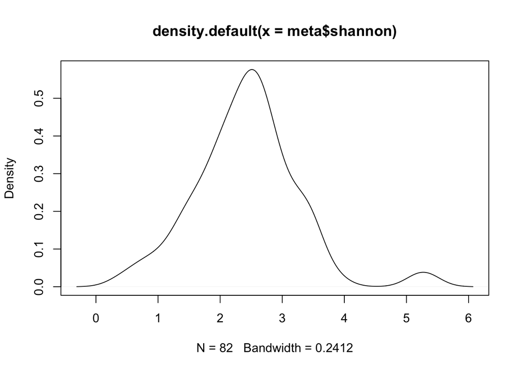

```r
plot(density(meta$shannon))
```

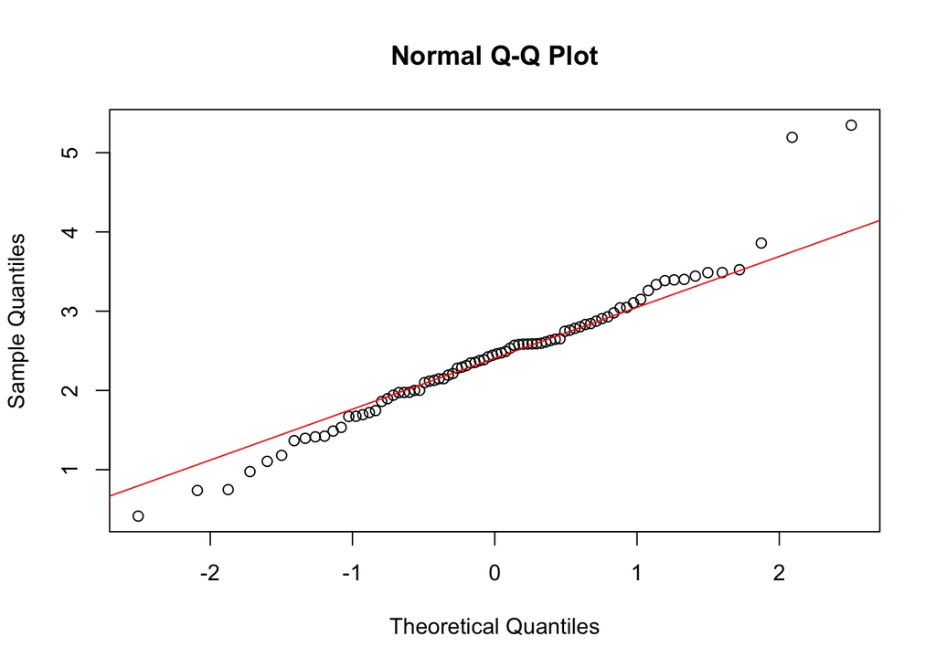

```r
# Plot using a qqplot
qqnorm(meta$shannon)
qqline(meta$shannon, col = 2)
```

## ANOVA

Model: Treatment*Time_Point with Treatment:Time_Point removed if not significant

```r
summary(aov(shannon ~ Treatment + as.factor(Time_Point) + Error(Subject_ID), data=meta))
```

```
##
## Error: Subject_ID
##           Df    Sum Sq   Mean Sq
## Treatment  1 8.727e-05 8.727e-05
##
## Error: Within
##                       Df Sum Sq Mean Sq F value Pr(>F)
## Treatment              1   3.20   3.195   4.685 0.0335 *
## as.factor(Time_Point)  2   1.33   0.667   0.978 0.3807
## Residuals             77  52.51   0.682
## ---
## Signif. codes:  0 '***' 0.001 '**' 0.01 '*' 0.05 '.' 0.1 ' ' 1
```

## Pairwise t-test

Model: Pairwise within Treatment:Time_Point groups

```r
pairwise.t.test(meta$shannon, meta$treat_time, p.adjust.method ="none")
```

```
##
##  Pairwise comparisons using t tests with pooled SD
##
## data:  meta$shannon and meta$treat_time
##
##           Drug_0 Drug_4 Drug_8 Placebo_0 Placebo_4
## Drug_4    0.660  -      -      -         -
## Drug_8    0.886  0.779  -      -         -
## Placebo_0 0.064  0.146  0.096  -         -
## Placebo_4 0.039  0.100  0.063  0.897     -
## Placebo_8 0.720  0.948  0.836  0.143     0.098
##
## P value adjustment method: none
```

## FDR correction

FDR correct alpha-diversity p-values

```r
p.adjust(c(0.660,0.886,0.779,0.897,0.143,0.098,0.064,0.100,0.836), method="fdr")
```

```
## [1] 0.89700 0.89700 0.89700 0.89700 0.32175 0.30000 0.30000 0.30000 0.89700
```

# Figures

Order Treatment:Time_Point groups

```r
meta$treat_time_ord = factor(meta$treat_time,c("Placebo_0","Drug_0","Placebo_4","Drug_4","Placebo_8","Drug_8"))
```

## Alpha boxplot

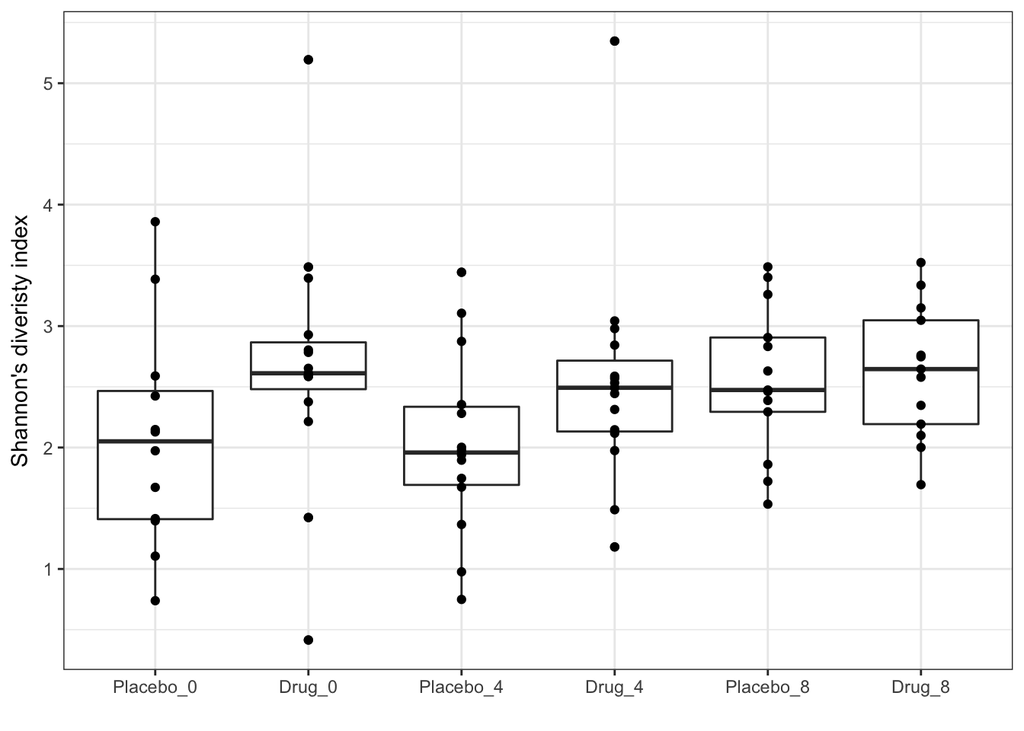

```r
ggplot(meta, aes(x=treat_time_ord, y=shannon)) +
  geom_boxplot() +
  geom_point() +
  theme_bw() +
  labs(y = "Shannon's diveristy index", x = "")
```

## Taxa boxplots

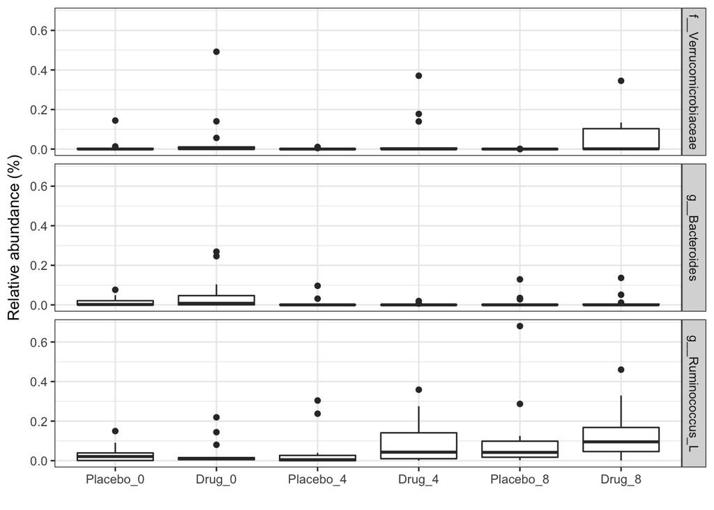

```r
#Select family of interest
fam.temp = fam.abund %>%
  rownames_to_column() %>%
  dplyr::select(rowname, f__Verrucomicrobiaceae)

#Select genera of interest
gen.temp = gen.abund %>%
  rownames_to_column() %>%
  dplyr::select(rowname, g__Bacteroides, g__Ruminococcus_L)

#merge with metadata
meta %>%
  rownames_to_column() %>%
  dplyr::select(rowname, treat_time, treat_time_ord) %>%
  full_join(fam.temp, by="rowname") %>%
  full_join(gen.temp, by="rowname") %>%
  rename(Sample=rowname) %>%
  #reformat to long
  gather(key="taxon", value="abund", -Sample, -treat_time, -treat_time_ord) %>%

  #plot
ggplot() +
  geom_boxplot(aes(x=treat_time_ord, y=abund)) +
  theme_bw() +
  labs(y = "Relative abundance (%)", x = "") +
  facet_grid(taxon~.)
```